# F9_06_GVRN_CHANGE_DOC_X

Made significant changes to governing documents [x] · Checkbox report

## Overview

**Description**

Organization made significant changes to organizing docs since last 990?

**Table**

`F9-P06-T00-GOVERNANCE` (one)

**Location code**

`F990-PC-PART-06-SECTION-A-LINE-04`, `F990-EZ-PART-05-LINE-34`

**Family**

`F990-PC-PART-06-SECTION-A-LINE-04`

**Data type**

checkbox (xsd: BooleanType, )

**Scope**

PZ

**Status**

unreviewed

5

xpaths mapped (4 observed)

5,981,036

filings with a value

2009–2024

tax years observed

2

open flags (1 errors)

## Flags

| Severity | Flag | Xpath | Detail |
| --- | --- | --- | --- |
| ⚠ error | `POLARITY` | IRS990EZ/ChgMadeToOrgnzngDocNotRptInd | negated element ‘ChgMadeToOrgnzngDocNotRptInd’ pooled with non-negated xpaths |
| ⓘ info | `UNOBSERVED` | IRS990/Form990PartVI/ChangesToOrganizingDocs | never observed in TY2009-2024 filings |

## Xpaths

All mapped xpaths (under /Return/ReturnData or /Return/ReturnHeader), oldest first. Charts label each series by its xpath.

| Xpath | Form | First year | Last year | Versions | Filings | Repeats in |
| --- | --- | --- | --- | --- | --- | --- |
| IRS990/ChangesToOrganizingDocs | 990 | 2009 | 2012 | 19 | 495,528 | 0.0% |
| IRS990EZ/MadeChangesToOrgnzngEtcDoc | 990-EZ | 2009 | 2012 | 18 | 254,594 | 0.0% |
| IRS990/ChangeToOrgDocumentsInd | 990 | 2013 | 2024 | 38 | 3,349,613 | 0.0% |
| IRS990EZ/ChgMadeToOrgnzngDocNotRptInd | 990-EZ | 2013 | 2024 | 38 | 1,881,301 | 0.0% |
| IRS990/Form990PartVI/ChangesToOrganizingDocs | 990 |  |  |  | 0 |  |

## Coverage

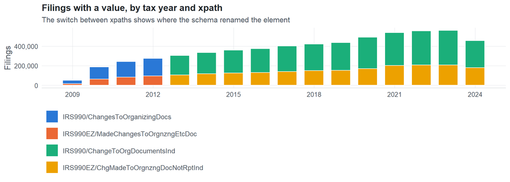

**Table view**

Table view: filings by tax year and series

| Tax year | IRS990/ChangesToOrganizingDocs | IRS990EZ/MadeChangesToOrgnzngEtcDoc | IRS990/ChangeToOrgDocumentsInd | IRS990EZ/ChgMadeToOrgnzngDocNotRptInd |
| --- | --- | --- | --- | --- |
| 2009 | 33,311 | 15,470 | 0 | 0 |
| 2010 | 123,025 | 63,326 | 0 | 0 |
| 2011 | 159,504 | 82,048 | 0 | 0 |
| 2012 | 179,688 | 93,750 | 0 | 0 |
| 2013 | 0 | 0 | 198,855 | 104,375 |
| 2014 | 0 | 0 | 218,619 | 116,417 |
| 2015 | 0 | 0 | 233,519 | 124,894 |
| 2016 | 0 | 0 | 243,903 | 130,484 |
| 2017 | 0 | 0 | 261,612 | 139,145 |
| 2018 | 0 | 0 | 271,442 | 149,384 |
| 2019 | 0 | 0 | 283,694 | 152,623 |
| 2020 | 0 | 0 | 320,343 | 169,865 |
| 2021 | 0 | 0 | 336,488 | 202,729 |
| 2022 | 0 | 0 | 349,062 | 206,135 |
| 2023 | 0 | 0 | 354,774 | 206,382 |
| 2024 | 0 | 0 | 277,302 | 178,868 |

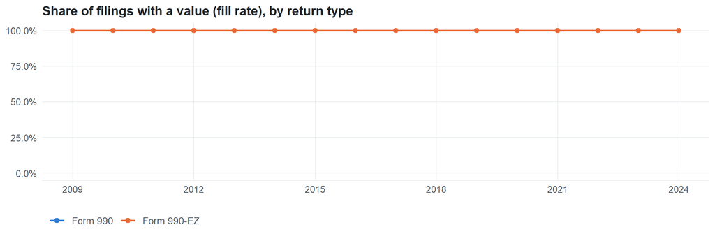

**Table view**

Table view: fill rate

| Tax year | Return type | Filings | All filings | Fill rate |
| --- | --- | --- | --- | --- |
| 2009 | Form 990 | 33,311 | 33,311 | 100.00% |
| 2009 | Form 990-EZ | 15,470 | 15,470 | 100.00% |
| 2010 | Form 990 | 123,025 | 123,025 | 100.00% |
| 2010 | Form 990-EZ | 63,326 | 63,326 | 100.00% |
| 2011 | Form 990 | 159,504 | 159,504 | 100.00% |
| 2011 | Form 990-EZ | 82,048 | 82,048 | 100.00% |
| 2012 | Form 990 | 179,688 | 179,688 | 100.00% |
| 2012 | Form 990-EZ | 93,750 | 93,750 | 100.00% |
| 2013 | Form 990 | 198,855 | 198,855 | 100.00% |
| 2013 | Form 990-EZ | 104,375 | 104,375 | 100.00% |
| 2014 | Form 990 | 218,619 | 218,619 | 100.00% |
| 2014 | Form 990-EZ | 116,417 | 116,417 | 100.00% |
| 2015 | Form 990 | 233,519 | 233,519 | 100.00% |
| 2015 | Form 990-EZ | 124,894 | 124,894 | 100.00% |
| 2016 | Form 990 | 243,903 | 243,903 | 100.00% |
| 2016 | Form 990-EZ | 130,484 | 130,484 | 100.00% |
| 2017 | Form 990 | 261,612 | 261,612 | 100.00% |
| 2017 | Form 990-EZ | 139,144 | 139,144 | 100.00% |
| 2018 | Form 990 | 271,442 | 271,442 | 100.00% |
| 2018 | Form 990-EZ | 149,384 | 149,384 | 100.00% |
| 2019 | Form 990 | 283,694 | 283,694 | 100.00% |
| 2019 | Form 990-EZ | 152,622 | 152,622 | 100.00% |
| 2020 | Form 990 | 320,342 | 320,342 | 100.00% |
| 2020 | Form 990-EZ | 169,864 | 169,864 | 100.00% |
| 2021 | Form 990 | 336,480 | 336,480 | 100.00% |
| 2021 | Form 990-EZ | 202,724 | 202,724 | 100.00% |
| 2022 | Form 990 | 349,055 | 349,055 | 100.00% |
| 2022 | Form 990-EZ | 206,130 | 206,130 | 100.00% |
| 2023 | Form 990 | 354,768 | 354,768 | 100.00% |
| 2023 | Form 990-EZ | 206,379 | 206,379 | 100.00% |
| 2024 | Form 990 | 277,298 | 277,298 | 100.00% |
| 2024 | Form 990-EZ | 178,867 | 178,867 | 100.00% |

## Values

| Result | Check | Detail |
| --- | --- | --- |
| ✓ pass | Values are checkbox codes | 100.0% of values are X / true / false / 1 / 0 |
| ⓘ info | Meaning of a blank | 99% of values are explicit false/0, so a missing value is not the same as unchecked |
| ⚠ fail | Element names agree in polarity | negated: ChgMadeToOrgnzngDocNotRptInd \| not negated: ChangeToOrgDocumentsInd, ChangesToOrganizingDocs, MadeChangesToOrgnzngEtcDoc |

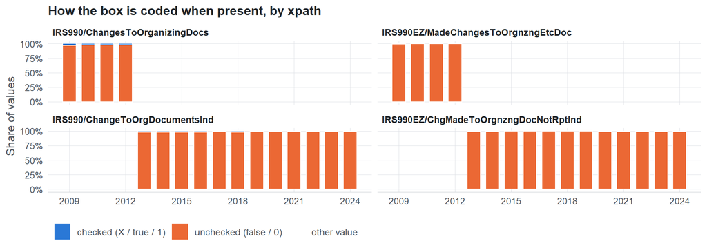

**Table view**

Table view: value coding by tax year

| Series | Tax year | Code | Filings | Share |
| --- | --- | --- | --- | --- |
| IRS990/ChangesToOrganizingDocs | 2009 | checked (X / true / 1) | 1,113 | 3.3% |
| IRS990/ChangesToOrganizingDocs | 2009 | unchecked (false / 0) | 32,198 | 96.7% |
| IRS990/ChangesToOrganizingDocs | 2010 | checked (X / true / 1) | 2,841 | 2.3% |
| IRS990/ChangesToOrganizingDocs | 2010 | unchecked (false / 0) | 120,184 | 97.7% |
| IRS990/ChangesToOrganizingDocs | 2011 | checked (X / true / 1) | 3,447 | 2.2% |
| IRS990/ChangesToOrganizingDocs | 2011 | unchecked (false / 0) | 156,057 | 97.8% |
| IRS990/ChangesToOrganizingDocs | 2012 | checked (X / true / 1) | 3,584 | 2.0% |
| IRS990/ChangesToOrganizingDocs | 2012 | unchecked (false / 0) | 176,104 | 98.0% |
| IRS990EZ/MadeChangesToOrgnzngEtcDoc | 2009 | checked (X / true / 1) | 134 | 0.9% |
| IRS990EZ/MadeChangesToOrgnzngEtcDoc | 2009 | unchecked (false / 0) | 15,336 | 99.1% |
| IRS990EZ/MadeChangesToOrgnzngEtcDoc | 2010 | checked (X / true / 1) | 342 | 0.5% |
| IRS990EZ/MadeChangesToOrgnzngEtcDoc | 2010 | unchecked (false / 0) | 62,984 | 99.5% |
| IRS990EZ/MadeChangesToOrgnzngEtcDoc | 2011 | checked (X / true / 1) | 397 | 0.5% |
| IRS990EZ/MadeChangesToOrgnzngEtcDoc | 2011 | unchecked (false / 0) | 81,651 | 99.5% |
| IRS990EZ/MadeChangesToOrgnzngEtcDoc | 2012 | checked (X / true / 1) | 467 | 0.5% |
| IRS990EZ/MadeChangesToOrgnzngEtcDoc | 2012 | unchecked (false / 0) | 93,283 | 99.5% |
| IRS990/ChangeToOrgDocumentsInd | 2013 | checked (X / true / 1) | 3,883 | 2.0% |
| IRS990/ChangeToOrgDocumentsInd | 2013 | unchecked (false / 0) | 194,972 | 98.0% |
| IRS990/ChangeToOrgDocumentsInd | 2014 | checked (X / true / 1) | 4,301 | 2.0% |
| IRS990/ChangeToOrgDocumentsInd | 2014 | unchecked (false / 0) | 214,318 | 98.0% |
| IRS990/ChangeToOrgDocumentsInd | 2015 | checked (X / true / 1) | 4,277 | 1.8% |
| IRS990/ChangeToOrgDocumentsInd | 2015 | unchecked (false / 0) | 229,242 | 98.2% |
| IRS990/ChangeToOrgDocumentsInd | 2016 | checked (X / true / 1) | 4,243 | 1.7% |
| IRS990/ChangeToOrgDocumentsInd | 2016 | unchecked (false / 0) | 239,660 | 98.3% |
| IRS990/ChangeToOrgDocumentsInd | 2017 | checked (X / true / 1) | 4,128 | 1.6% |
| IRS990/ChangeToOrgDocumentsInd | 2017 | unchecked (false / 0) | 257,484 | 98.4% |
| IRS990/ChangeToOrgDocumentsInd | 2018 | checked (X / true / 1) | 4,490 | 1.7% |
| IRS990/ChangeToOrgDocumentsInd | 2018 | unchecked (false / 0) | 266,952 | 98.3% |
| IRS990/ChangeToOrgDocumentsInd | 2019 | checked (X / true / 1) | 4,297 | 1.5% |
| IRS990/ChangeToOrgDocumentsInd | 2019 | unchecked (false / 0) | 279,397 | 98.5% |
| IRS990/ChangeToOrgDocumentsInd | 2020 | checked (X / true / 1) | 4,707 | 1.5% |
| IRS990/ChangeToOrgDocumentsInd | 2020 | unchecked (false / 0) | 315,636 | 98.5% |
| IRS990/ChangeToOrgDocumentsInd | 2021 | checked (X / true / 1) | 4,739 | 1.4% |
| IRS990/ChangeToOrgDocumentsInd | 2021 | unchecked (false / 0) | 331,749 | 98.6% |
| IRS990/ChangeToOrgDocumentsInd | 2022 | checked (X / true / 1) | 4,723 | 1.4% |
| IRS990/ChangeToOrgDocumentsInd | 2022 | unchecked (false / 0) | 344,339 | 98.6% |
| IRS990/ChangeToOrgDocumentsInd | 2023 | checked (X / true / 1) | 4,885 | 1.4% |
| IRS990/ChangeToOrgDocumentsInd | 2023 | unchecked (false / 0) | 349,889 | 98.6% |
| IRS990/ChangeToOrgDocumentsInd | 2024 | checked (X / true / 1) | 3,572 | 1.3% |
| IRS990/ChangeToOrgDocumentsInd | 2024 | unchecked (false / 0) | 273,730 | 98.7% |
| IRS990EZ/ChgMadeToOrgnzngDocNotRptInd | 2013 | checked (X / true / 1) | 502 | 0.5% |
| IRS990EZ/ChgMadeToOrgnzngDocNotRptInd | 2013 | unchecked (false / 0) | 103,873 | 99.5% |
| IRS990EZ/ChgMadeToOrgnzngDocNotRptInd | 2014 | checked (X / true / 1) | 544 | 0.5% |
| IRS990EZ/ChgMadeToOrgnzngDocNotRptInd | 2014 | unchecked (false / 0) | 115,873 | 99.5% |
| IRS990EZ/ChgMadeToOrgnzngDocNotRptInd | 2015 | checked (X / true / 1) | 548 | 0.4% |
| IRS990EZ/ChgMadeToOrgnzngDocNotRptInd | 2015 | unchecked (false / 0) | 124,346 | 99.6% |
| IRS990EZ/ChgMadeToOrgnzngDocNotRptInd | 2016 | checked (X / true / 1) | 536 | 0.4% |
| IRS990EZ/ChgMadeToOrgnzngDocNotRptInd | 2016 | unchecked (false / 0) | 129,948 | 99.6% |
| IRS990EZ/ChgMadeToOrgnzngDocNotRptInd | 2017 | checked (X / true / 1) | 588 | 0.4% |
| IRS990EZ/ChgMadeToOrgnzngDocNotRptInd | 2017 | unchecked (false / 0) | 138,557 | 99.6% |
| IRS990EZ/ChgMadeToOrgnzngDocNotRptInd | 2018 | checked (X / true / 1) | 585 | 0.4% |
| IRS990EZ/ChgMadeToOrgnzngDocNotRptInd | 2018 | unchecked (false / 0) | 148,799 | 99.6% |
| IRS990EZ/ChgMadeToOrgnzngDocNotRptInd | 2019 | checked (X / true / 1) | 634 | 0.4% |
| IRS990EZ/ChgMadeToOrgnzngDocNotRptInd | 2019 | unchecked (false / 0) | 151,989 | 99.6% |
| IRS990EZ/ChgMadeToOrgnzngDocNotRptInd | 2020 | checked (X / true / 1) | 857 | 0.5% |
| IRS990EZ/ChgMadeToOrgnzngDocNotRptInd | 2020 | unchecked (false / 0) | 169,008 | 99.5% |
| IRS990EZ/ChgMadeToOrgnzngDocNotRptInd | 2021 | checked (X / true / 1) | 1,311 | 0.6% |
| IRS990EZ/ChgMadeToOrgnzngDocNotRptInd | 2021 | unchecked (false / 0) | 201,418 | 99.4% |
| IRS990EZ/ChgMadeToOrgnzngDocNotRptInd | 2022 | checked (X / true / 1) | 1,237 | 0.6% |
| IRS990EZ/ChgMadeToOrgnzngDocNotRptInd | 2022 | unchecked (false / 0) | 204,898 | 99.4% |

First rows shown.

Raw values by xpath (all years)

| Series | Value | Filings |
| --- | --- | --- |
| IRS990/ChangesToOrganizingDocs | false | 268,819 |
| IRS990/ChangesToOrganizingDocs | 0 | 215,724 |
| IRS990/ChangesToOrganizingDocs | 1 | 6,489 |
| IRS990/ChangesToOrganizingDocs | true | 4,496 |
| IRS990EZ/MadeChangesToOrgnzngEtcDoc | false | 177,549 |
| IRS990EZ/MadeChangesToOrgnzngEtcDoc | 0 | 75,705 |
| IRS990EZ/MadeChangesToOrgnzngEtcDoc | true | 825 |
| IRS990EZ/MadeChangesToOrgnzngEtcDoc | 1 | 515 |
| IRS990/ChangeToOrgDocumentsInd | false | 2,004,813 |
| IRS990/ChangeToOrgDocumentsInd | 0 | 1,292,555 |
| IRS990/ChangeToOrgDocumentsInd | 1 | 30,354 |
| IRS990/ChangeToOrgDocumentsInd | true | 21,891 |
| IRS990EZ/ChgMadeToOrgnzngDocNotRptInd | false | 1,391,558 |
| IRS990EZ/ChgMadeToOrgnzngDocNotRptInd | 0 | 479,828 |
| IRS990EZ/ChgMadeToOrgnzngDocNotRptInd | true | 6,398 |
| IRS990EZ/ChgMadeToOrgnzngDocNotRptInd | 1 | 3,517 |

## Examples

| Tax year | Return | Xpath | Organization | Value | Source |
| --- | --- | --- | --- | --- | --- |
| 2024 | 990 | IRS990/ChangeToOrgDocumentsInd | IAAI FOUNDATION INC | false | [XML](https://gt990datalake-rawdata.s3.amazonaws.com/EfileData/XmlFiles/202523089349301317_public.xml) |
| 2024 | 990EZ | IRS990EZ/ChgMadeToOrgnzngDocNotRptInd | Science & Technology Education Project | false | [XML](https://gt990datalake-rawdata.s3.amazonaws.com/EfileData/XmlFiles/202531709349200103_public.xml) |
| 2023 | 990 | IRS990/ChangeToOrgDocumentsInd | MACKINAC ASSOCIATES | false | [XML](https://gt990datalake-rawdata.s3.amazonaws.com/EfileData/XmlFiles/202530469349300808_public.xml) |
| 2023 | 990EZ | IRS990EZ/ChgMadeToOrgnzngDocNotRptInd | SAN ANTONIO HOMESCHOOL ATHLETIC ASSOICATION | false | [XML](https://gt990datalake-rawdata.s3.amazonaws.com/EfileData/XmlFiles/202432609349201843_public.xml) |
| 2022 | 990 | IRS990/ChangeToOrgDocumentsInd | FRANK TOWN OPEN HEARTS MINISTRY INC | 0 | [XML](https://gt990datalake-rawdata.s3.amazonaws.com/EfileData/XmlFiles/202303189349302170_public.xml) |
| 2022 | 990EZ | IRS990EZ/ChgMadeToOrgnzngDocNotRptInd | Dana Point Post 9934 Veterans of Foreign Wars | 0 | [XML](https://gt990datalake-rawdata.s3.amazonaws.com/EfileData/XmlFiles/202342379349201129_public.xml) |
| 2021 | 990 | IRS990/ChangeToOrgDocumentsInd | AFRICA NETWORK FOR ANIMAL WELFARE- USA | false | [XML](https://gt990datalake-rawdata.s3.amazonaws.com/EfileData/XmlFiles/202222209349300402_public.xml) |
| 2021 | 990EZ | IRS990EZ/ChgMadeToOrgnzngDocNotRptInd | BLAINE 1 INC | false | [XML](https://gt990datalake-rawdata.s3.amazonaws.com/EfileData/XmlFiles/202201369349200340_public.xml) |
| 2020 | 990 | IRS990/ChangeToOrgDocumentsInd | CHARLOTTE HARBOR WATER ASSOCIATION INC | 0 | [XML](https://gt990datalake-rawdata.s3.amazonaws.com/EfileData/XmlFiles/202132739349301608_public.xml) |
| 2020 | 990EZ | IRS990EZ/ChgMadeToOrgnzngDocNotRptInd | ESAN UNITED DALLAS FORT WORTH | false | [XML](https://gt990datalake-rawdata.s3.amazonaws.com/EfileData/XmlFiles/202143169349202839_public.xml) |
| 2019 | 990 | IRS990/ChangeToOrgDocumentsInd | FOSTERING HOPE | 0 | [XML](https://gt990datalake-rawdata.s3.amazonaws.com/EfileData/XmlFiles/202033519349300713_public.xml) |
| 2019 | 990EZ | IRS990EZ/ChgMadeToOrgnzngDocNotRptInd | LIONS INTERNATIONAL ROSELLE | false | [XML](https://gt990datalake-rawdata.s3.amazonaws.com/EfileData/XmlFiles/202023219349200802_public.xml) |

## Reviewer checklist

- The definition matches the form line and instructions for every xpath’s schema years.
- Every xpath pooled here measures the same thing on the 990 and 990-EZ (close enough for analysis).
- The coverage chart has no unexplained gaps or jumps between tax years.
- Each open flag is fixed, or accepted with a note in validation_log.csv.
- The box means the same thing (and the same polarity) under every xpath: ‘required’ is never pooled with ‘not required’.
- Absent means unchecked for this line, or the question was skipped; the data dictionary says which.
- Yes/No questions coded as two separate boxes are mapped to one variable only when that is intended.

Record the review as a row in `inst/extdata/src/validation_log.csv` (variable_name, reviewer, date, status, note). Evidence built 2026-09-23 17:09:04 MST from the ef2 DuckDB builds (tax years 2009–2024).